# [pennatia](http://localhost:1313/)

## b) Apply your implementation using either the Iris data or the features generated from HW 2.

### i. Use the top two ranked features.

To extract the top two ranked features, we will leverage pandas' slicing options to only extract **petal length** and **petal width**. We will create a labeled and unlabeled set, which will prove useful as the exercise continues.

```python
train_data = iris_data[['petal_width','petal_length']]
train_data_labeled = iris_data[['petal_width','petal_length','species']]
```

### ii. Create 3 clusters for the Iris data or 4 clusters using the 4 numerical values that have the best separation.

We will create the clusters using the Class and function we defined above. To do this, we will:

- Create a GaussianMixModel object, containing the necessary parameters (the dataset defined in the step above, and the number of clusters).
- Call the .fit() function we have built in order to trigger the EM loop defined above.
- Extract the means, covariances and z's (probability of each point for each distribution)

Given what we have specified in the .fit() portion of our implementation, the code below will print whether convergence was reached and at what iteration.

```python
# Create GaussianMixModel with indicated parameters
gauss = GaussianMixModel(train_data,k=3)

# Fit model to our Data
gauss.fit()

# Extract means, covariances, and Z's
means = np.array(gauss.mean_arr)
covs = gauss.sigma_arr
zs = gauss.Z
```

```
Converged at iteration 36.
```

### iii. Display the 3 species or 4 numerical values using different colors for a good visual representation.

In the space below, we will plot the output of our Gaussian Mixture Model. To do this, we will take the following steps:

- Generate multivariate pdf's for each of the means and covariances outputted by the code above.
- Create a meshgrid of points in linear space (using the minimums and maximums from our original dataset) in order to plot a representation of the generated mutlivariate pdfs. Essentially, these will be used to generate ellipsoids that will provide a representation of the shape and orientation of our three resultant multivariate normal PDFs.
- These will be plotted using matplotlib's .contour() function, which will assign (by default) seven contours to each distribution.
- We will plot these using the three colors we have usually used.
- We will also plot the original data (with a low transparency), underneath the multivariate distribution ellipsoids to have a visual representation of how well our clustering is performing.

Please note that the plotted datapoints simply represent the original datasaet, whereas the ellipsoid are representative of the clusters generated using our Expectation Maximization implementation. Please note also that the color assignment is random (as the location of the means within the output dataframe is random). The colors are aligned because I performed the plotting and calculation until they matched.

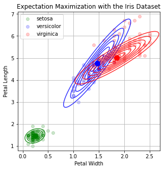

```python
# Convert dataset to array for ease of meshgrid creation
X = np.array(train_data)

# Create Linear Space Matrix for Plotting Gaussians Mixtures
lin_x = np.linspace(np.min(X[:,0])-0.2, np.max(X[:,0]) + 0.2, 200)
lin_y = np.linspace(np.min(X[:,1])- 0.2, np.max(X[:,1])+0.2, 200)
ac, db = np.meshgrid(lin_x,lin_y)

# Initialize Plot
fig = plt.figure(figsize=(5,5))
ax0 = fig.add_subplot(111)

# Create color dictionaries & iterable
species = ['setosa','versicolor','virginica']
colors_1 = {0: 'green', 1:'blue', 2: 'red'}
colors_2 = {'setosa': 'green', 'versicolor':'blue', 'virginica': 'red'}

# Plot each species (original data) in a different color
for specie in species:
    temp = train_data_labeled[train_data_labeled['species'] == specie]
    ax0.scatter(temp['petal_width'], temp['petal_length'], label = specie,
    c = colors_2[specie], alpha = 0.2)
ax0.legend()
ax0.grid()

# Iterate through the means and covariances and plot the Guassians
for i in range(len(means)):
    m = means[i]
    c = covs[i]
    multi_normal = multivariate_normal(mean=m,cov=c)
    pos = np.dstack((ac,db))
    ax0.contour(ac,db,multi_normal.pdf(pos), colors = colors_1[i], alpha = 0.8)
    ax0.scatter(m[0],m[1],c=colors_1[i],zorder=10,s=100)
    ax0.set_xlabel('Petal Width')
    ax0.set_ylabel('Petal Length')
plt.title("Expectation Maximization with the Iris Dataset")
plt.show()
```

Though our algorithm seems to be performing adequately in attempting to cluster our data, it is worth exploring other implementations and built-ins to check whether its performance is comparable to that of implementations compiled by other, more accomplished Data Scientists.

### Compare to a pre-built Gaussian Mixture Model | sklearn

Here we will try to compare our output with **sklearn's GaussianMixture** built-in function. Please note that sklearn's Gaussian Mixture model initiates its parameters using one of the following ways:

- Random
- KMeans (it will perform KMeans to determine where to initialize the means and covariances)

We will be testing the performance of both implementations below. The code for plotting will looking exactly like that above, so I will spare you a description of its steps. What follows below is a representation of the GaussianMixture built-in initialized with a random state. Please note again that the color assignment is random (as the location of the means within the output dataframe is random). The colors are aligned because I performed the plotting and calculation until they matched.

```
Converged: True
Number of Iterations: 19
```

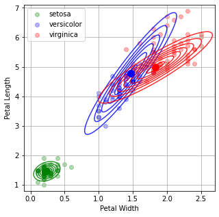

```python
# Convert dataset to array for ease of meshgrid creation
X = np.array(train_data)

# Create meshgrid for plotting Gaussian Mixtures
lin_x = np.linspace(np.min(X[:,0])-0.2, np.max(X[:,0]) + 0.2, 200)
lin_y = np.linspace(np.min(X[:,1])- 0.2, np.max(X[:,1])+0.2, 200)
ac, db = np.meshgrid(lin_x,lin_y)

# Perform EM with built-in sklearn function
GMM = GaussianMixture(n_components = 3, init_params = 'random').fit(X)
print(f'Converged: {GMM.converged_}')
print(f'Number of Iterations: {GMM.n_iter_}')
means_skl = GMM.means_
covariances_skl = GMM.covariances_

# Initialize the plots
fig = plt.figure(figsize=(5,5))
ax0 = fig.add_subplot(111)

# Initialize color dictionary
colors = {'setosa': 'green',
'versicolor':'blue',
'virginica': 'red'}

colors_1 = {0: 'green',
1:'blue',
2: 'red'}
species = ['setosa','versicolor','virginica']

# Plot each data point in assigned color
for specie in species:
    temp = train_data_labeled[train_data_labeled['species'] == specie]
    ax0.scatter(temp['petal_width'], temp['petal_length'], label = specie,
    c = colors[specie], alpha = 0.3)
ax0.legend()
ax0.grid()

# Plot the contours using the
for i in range(len(means)):
    m = means_skl[i]
    c = covariances_skl[i]
    multi_normal = multivariate_normal(mean=m,cov=c)
    pos = np.dstack((ac,db))
    ax0.contour(ac,db,multi_normal.pdf(pos), colors = colors_1[i], alpha = 0.8)
    ax0.scatter(m[0],m[1],c=colors_1[i],zorder=10,s=100)
    ax0.set_xlabel('Petal Width')
    ax0.set_ylabel('Petal Length')
plt.show()
```

Using sklearn's Gaussian Mixture models with random initial parameters, we actually convergence to pretty much the exact same clustering as our model did! This was a very satisfying thing to see. However, it's worth having a look at the clustering model's performance when the initial parameters are created using KMeans. Having a look at how things change when incorporating different models within the one we have built is an interesting exercise and may prove fruitful in deciding which steps to take first when faced with a new analysis vertical. Please note again that the color assignment is random (as the location of the means within the output dataframe is random). The colors are aligned because I performed the plotting and calculation until they matched.

```
Converged: True
Number of Iterations: 3
```

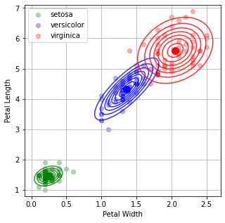

```python
# Convert dataset to array for ease of meshgrid creation
X = np.array(train_data)

# Create meshgrid for plotting Gaussian Mixtures
lin_x = np.linspace(np.min(X[:,0])-0.2, np.max(X[:,0]) + 0.2, 200)
lin_y = np.linspace(np.min(X[:,1])- 0.2, np.max(X[:,1])+0.2, 200)
ac, db = np.meshgrid(lin_x,lin_y)

# Perform EM with built-in sklearn function
GMM = GaussianMixture(n_components = 3, init_params = 'kmeans').fit(X)
print(f'Converged: {GMM.converged_}')
print(f'Number of Iterations: {GMM.n_iter_}')
means_skl = GMM.means_
covariances_skl = GMM.covariances_

# Initialize the plots
fig = plt.figure(figsize=(5,5))
ax0 = fig.add_subplot(111)

# Initialize color dictionary
colors = {'setosa': 'green',
'versicolor':'blue',
'virginica': 'red'}

colors_1 = {0: 'green',
1:'blue',
2: 'red'}
species = ['setosa','versicolor','virginica']

# Plot each data point in assigned color
for specie in species:
    temp = train_data_labeled[train_data_labeled['species'] == specie]
    ax0.scatter(temp['petal_width'], temp['petal_length'], label = specie,
    c = colors[specie], alpha = 0.3)
ax0.legend()
ax0.grid()

# Plot the contours using the
for i in range(len(means)):
    m = means_skl[i]
    c = covariances_skl[i]
    multi_normal = multivariate_normal(mean=m,cov=c)
    pos = np.dstack((ac,db))
    ax0.contour(ac,db,multi_normal.pdf(pos), colors = colors_1[i], alpha = 0.8)
    ax0.scatter(m[0],m[1],c=colors_1[i],zorder=10,s=100)
    ax0.set_xlabel('Petal Width')
    ax0.set_ylabel('Petal Length')
plt.show()
```

This makes for an incredibly interesting and easy-to-comprehend visualization of the value and importance of the Data Scientist's decision-making.

# Problem 2 - Artificial Intelligence

## Define in your own words the following terms:

- **Agent**: within the definitions applying to artificial intelligence, an agent is an entity that can understand (or internally represent) a sensed environment, and act. The agent's action must hence be based on its perceived environment. An agent is an entity that makes decisions and/or operations based on the environment it senses.
- **Agent Function**: an agent function represents the correspondence between sensed environment and chosen action. In other words, the agent function maps the agent's various environmental sensations or representations to a given action.
- **Agent Program**: the agent program is essentially what "implements" the agent function. The agent program translates the outcome of the agent function to a tangible physical action.
- **Artificial Intelligence**: An artificial intelligence is a computational entity capable of thinking and acting like a human, and of thinking and acting rationally. More focus must be placed on the latter, as definitions become somewhat hazy when definining what "thinking and acting humanly" is like. With most current Artificial Intelligence entities, the focus in on rational acting, though much study is being devoted to language processing and the general mimicking of human-based thought processes.
- **Autonomy**: Once created, we call an artificial intelligence autonomous if it can perform the task it was designed for without the help or input of a human. With the vacuum example, autonomy entails directing its cleaning throughout the house without any input from an owner. For an AI vacuum to be fully autonomous, however, there also needs to be checks put in places for charging and battery consumption. As such, a fully autonomous AI vacuum would have the ability to recognize its own low-battery levels and plug itself into the charger (as my Roomba does dutifully). In broader terms, autonomy is defined as the lack of human-input in performance. Within the emerging fields of AI, autonomy is also applied to learning, where Artificial Intelligence entities are capable of learning without the input or supervision of any formal human intelligence.
- **Goal-based agent**: A goal-based agent keeps track of given factors in its environment in order to perform the task it is trying to achieve. Given the set of environmental variables it monitors, a goal-based agent will then always action a plan geared towards achieving its goals. In other words, a goal based agent continously checks whether its goal is achieved. If it isn't currently achieved, it calculates the necessary series of actions to achieve it. If environmental conditions change, then the goal-based agent will upadte its internal plan and try to achieve the goal once more.
- **Intelligence**: Pages could be written to define Intelligence as a whole. Many would define it as the capability for rational and logical thought. In other words, the ability to conceptualize a number of conditional or iterative statements about the world. Though within our sphere of experience intelligence can be emotional, physical, and rational, within the realm of AI, intelligence is usually analogous to the ability to rationalize, and, in certain cases, to the ability to learn. Some (including our lecture notes) have dubbed the four major components of AI to be knowledge, reasoning, language understanding and learning. These are excellent indicators for most common definitions of intelligence. While not all of them are required for an entity to be defined an "artificial intelligence", our human definition of intelligence certainly captures all four.
- **Learning agent**: A learning agent is designed with the intent of completing a given task, but also with the intent of learning while doing so. As such, a learning agent can garner further knowledge from its past instances and enforce such learnings upon its future actions. Generally, learning agents will have a learning element. This element will generally be tasked with attempting changes within its agent functions based on feedback entering through the "critic". The "critic" in turn is responsible for grathering information about the agent's performance from the environment, and determining metrics to assess the agent's performance. Feedback about the agent's performance from the critic is fed to the learning element. The performance element and problem generator work in tandem. The perforamnce element selects a given action, while the problem generator serves as more of a "suggestor", feeding the performance element "suggestions" which will also be conducive to the agent's learning.
- **Logical reasoning**: A type of reasoning which uses deduction, induction or abduction to understand a given phenomenon, or to plan a certain action. In other words, a way of reasoning in which phenomena are divided into a series of conditional statements that a given agent can influence and/or infer from.
- **Model-based agent**: A model based agent is essentially one that is driven by some kind of model about its perceived world. As its sensors take in its environment, its model parameters are updated, and certain actions are taken or not. Often, model based agents are able to keep track of the previous environmental conditions as part of their model. Therefore, model-based agents essentially update their current working model of the environment and use said updates to guide actions. The way its actions then impact the environment is also registered (and therefore also impacts its perception), in a great loop of environment action & perception.
- **Rationality**: within the field of AI, rationality is the choice of actions and plans that allow the agent to maximize its performance given its metrics. (i.e. maximing the expected value of the performance measure -- not my own words, but I think the neatest.)
- **Reflex agent**: a reflex agent is amongst the simplest types of agents. A reflex agent essentially checks for one or more conditions, and performs an action if that condition is met/not met.
- **Utility-based agent**: utility-based agents work with the same principles of goal-based agents. In other words, they keep track of given factors in their environment in order to perform the task they are trying to achieve. They come up with plans surrounding eventualities and changes in their environments, in order to reach their goals. The primary difference between utility-based agents and goal-based agents lies within the fact that utility-based agent don't always have a "fulfillment" condition, whereby their goal is achieved. Often times, utility-based agents are created just to continously "maximize".

# Problem 3 - Cross validation

## a) Develop an algorithm to randomly separate data into groups of testing and training groups based on the number of desired folds/experiments, the term used will be k-fold cross validation.

In order to accomplish to create our k-fold algorithm, it is helpful to refer to Figure 1 in the Homework file, which we will represent here:

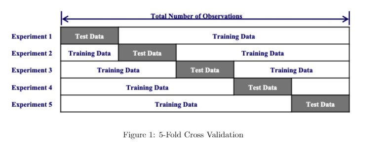

```python
display.Image('media/Kfold.jpg')
```

Essentially, a KFold algorithm must then divide the data into a number of desired chunks, and "move" through it, separating it into train and test data each time. To implement this concept, we will:

- Calculate the size of the folds
- Iterate a number of times equal to the number of folds
- Create a moving indexer that will shift by the size of the folds at each iteration
- Extract the training and testing sets and save them to two separate dictionaries which will be indexed by the "fold" number.

Since I had some extra time, I decided to attempt to build a few extra functionalities to my KFold algorithm:

- The algorithm will be able to randomize the data fed into it, by passing "randomize = True" as an argument
- The algorithm will be able to provide an even split of labels (if the data is labeled) in each set, should that be mathematically feasible.

These two extra functionalities will be able to work with each other, since randomization will occur first. As such, the data will be randomized first, and then shuffled to represent an equal distribution of labels, which our moving iterator can slice through.

## b) Implement your k-fold cross validation algorithm.

My implementation of KFold follows below, following this logic:

- If randomization is desired, randomize the inputted dataset
- If a label list provided, reorder the dataset such that each label is presented once every *number_of_labels* entries.
- Calculate the number of observations per fold
- Initialize the iterative mover and the output arrays
- Iterate over the number of folds, moving the iterator (id_mover) to the next slice, and splitting the dataset into a training and testing portion
- Save the output to the corresponding fold index within the output dictionaries.

Please note that the code below will always generate a new index in ascending order. Should we desire to keep the original index, removing the .reset_index() where it appears will allow this functionality as well.

```python
def kFold(dataset,folds, label_list, randomize = bool):

    # Shuffle data if desired
    if randomize == True:
        dataset = dataset.sample(frac = 1).reset_index(drop = True)

    # Space Labels out evenly if desired
    if label_list != None:
        labels_ = np.array(label_list)
        l_ids = []
        for i in range(len(np.unique(labels_))):
            l_ids += np.where(labels_ == np.unique(labels_)[i])
        l_ids = np.array(l_ids)
        new_ids = []
        for i in range(l_ids.shape[1]):
            for k in range(l_ids.shape[0]):
                new_ids.append(l_ids[k,i])

        dataset = dataset.iloc[new_ids].reset_index(drop=True)

    # Define number of observations per fold
    obs_per_fold = int(len(dataset)/folds)

    # Initialize moving-indexer and outputs
    id_mover = []
    k_fold_train = {}
    k_fold_test = {}

    # Move indexer through data and extract train and test sets
    # Returns two dictionaries of datasets of len = k
    for i in range(folds):
        id_mover = [obs_per_fold*i, obs_per_fold*i + obs_per_fold]
        k_fold_test[i] = dataset.iloc[id_mover[0]:id_mover[1]]
        k_fold_train[i] = dataset.drop(k_fold_test[i].index)

    return k_fold_train, k_fold_test
```

## c) Test your implementation using either the Iris data set or the numerical features generated from HW2.

We will test our implementation below, by employing our KFold alogrithm to generate 5 slices from the Iris DataSet, using the train_data variable generated earlier, as well as a labels list. We will further specify that we want our data randomized, and that we will be passing in a labels list, such as to maintain an even spread of classes per testing and training fold.

We will then show the output of the dictionary by calling one of its fold-indexes for the test-set. We will call index 1 (the second fold, given Python's notation), which should display index number 30-59, if our implementation was correct.

```python
labels_ = iris_data['species']
train_dataset, test_dataset = kFold(train_data, 5, labels_, True)

test_dataset[1]
```

|  | petal_width | petal_length |
| --- | --- | --- |
| 30 | 0.3 | 1.3 |
| 31 | 2.3 | 5.9 |
| 32 | 1.3 | 4.5 |
| 33 | 2.0 | 5.1 |
| 34 | 0.2 | 1.5 |
| 35 | 1.0 | 3.7 |
| 36 | 0.2 | 1.4 |
| 37 | 1.5 | 5.1 |
| 38 | 1.3 | 3.6 |
| 39 | 2.0 | 6.4 |
| 40 | 0.2 | 1.4 |
| 41 | 1.8 | 6.0 |
| 42 | 2.3 | 5.1 |
| 43 | 2.2 | 5.6 |
| 44 | 1.3 | 4.2 |
| 45 | 1.9 | 5.0 |
| 46 | 1.5 | 4.9 |
| 47 | 0.1 | 1.4 |
| 48 | 1.3 | 4.0 |
| 49 | 1.3 | 4.6 |
| 50 | 1.2 | 4.7 |
| 51 | 1.1 | 3.0 |
| 52 | 1.2 | 4.4 |
| 53 | 1.8 | 5.6 |
| 54 | 1.0 | 3.5 |
| 55 | 1.3 | 4.4 |
| 56 | 1.1 | 3.9 |
| 57 | 0.2 | 1.3 |
| 58 | 1.2 | 3.9 |
| 59 | 0.2 | 1.5 |

## d) Perform analysis and provide an explanation of how each k-fold creates subsets of the data, e.g., training and testing sets.

Given the iterative process, the code we have generated will run in $O(k)$ time, where $k$ represents the number of folds. The underlying mechanism of KFold and sequently of our implementation are rather simple, and they follow the logic outlined below:

- The desired number of folds is a required **input**.
- Once the desired number of folds is known, it is possible to devise how many observations will be present per fold by dividing the length of the dataset by the total number of folds desired. If this result is uneven, it is up to the data scientist to determine the continuation (i.e. whether to cut data, or to have a certain fold hold fewer values)
- Once the number of observations per fold is known, we can begin to move through the data (as per Figure 1) and create test slices using a moving iterator.
- Once we have created a test slice, we create the train slice by simply using the rest of the array that has not been sliced.
- We iterate through the process above *k* times, until our k folds cover the entirety of the dataset.

With the logic above, each observation within a dataset can be used as a testing point.

# Problem 4 | Machine Learning: Parzen Window

## a) Using the Gaussian kernel develop psuedo code to create a Parzen windowing system to accomplish the following steps:

- Develop the ability to read in data xn with n observations and D dimensions (number of features).
- Using the Gaussian kernel in Eq. 24 of the Machine Learning document to develop an algorithm to process an input observations and compare it with the training observations.
- Expand the development to handle multiple classes.
- [5 point bonus] use your solution from Problem 3 for a 5-fold cross validation implementation with the Parzen Window.

In order to accomplish this task, we will split the development and implementation of our code to perform three key functions:

- GaussianKernel Function: this function will follow Eq. 24 of the Machine Learning document, and will accept a given point, a dataset, a bandwidth scalar "h", and a given number of dimensions with which to operate.
- Base Parzen Estimation Function: will taken in a training dataset, as well as a test set and bandwidth scalar "h". The function will itereate through each test point in the test set, and each training point in teh training set, in order to generate the test-points' associated probabilities (by calling the Kernel Function upon these inputs).
- Class_based Parzen Estimation Function: this function will essentially contain the same loop as we will create for the base estimator, but find it nested within another class-iteartor. As such,for each test-point it will output the probabilities associated with each of the classes. Please note that this function will require a label list in order to determine the classes.

The Gaussian Kernel we define below will take the form of Eq. 24 of the Machine Learning document, which is reported below:

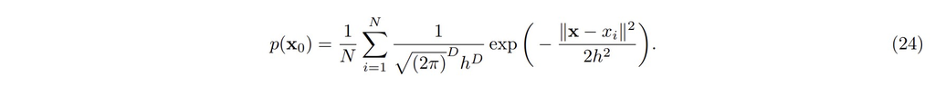

```python
display.Image("Media/Gaussian Kernel.jpg")
```

```python
def GaussianKernel(point_x, dataset, h, D):

    # Perform point-by-point subtraction
    norm_vec = np.linalg.norm(point_x - dataset)

    # Define left-side of the equation
    lf = 1/((math.sqrt(2*math.pi))**D)

    # Exponentiate right-side of the equation
    exp_eq = -0.5*((norm_vec/h)**2)

    # Multiply the two and return result
    g = lf * math.exp(exp_eq)
    return g
```

The code below will then create a parzen window around the Gaussian Kernel we have just created. Its operating logic will be simple, and it will follow these simple steps:

- Extract dimensions of relevant training and test set
- Initialize variables necessary for iteration
- Establish Gaussian Kernel for each test point and datapoint in the sets, and keep a running sum of its outputs as we iterate through the sets. **Please note** that this iteration is equivalent to the summing expression in Equation 24. As such, once we have exited the loop and finished our sum, we will multiply by (1/n)/
- Return the probability of each point in the dataset belonging to the given distribution.

```python
def parzen_estimation(training_set, test_set, h):

    # Reshape data for ease of treatment
    input_data = np.array(training_set)
    test_set = np.array(test_set)

    # Initialize parameters necessary for iteration
    N,D = input_data.shape
    test_n = test_set.shape[0]
    P_i = np.zeros((test_n))

    # Iterate over test and train sets
    for z in range(test_n):
        p_sums = 0.0
        for i in range(N):

            # Establish Gaussian Kernel Density by summing outputs of
            # Gaussian Function defined above
            g_k_v = GaussianKernel(test_set[z], input_data[i], h, D)
            p_sums += (1/h**D)*(g_k_v)

        # Divide by total number of entries in dataset (as per EQ. 24)
        P_i[z] = (p_sums/N)

    return P_i
```

In this last portion, we will expand on the above to handle multiple classes. The function below will essentially perform the same operation as the above, but with the ability to taken in a vector of labels and return the probabilities of belonging to each of the classes present within the label set. **Please note** that the indices of the label set must match the indices of the train data being fed into the model. The function below will opeate with the following logic:

- Iterate over a number "K" of classes.
- Extract the indices of the current class from the total set, and only pass data with those indexes through the same parzen window function we defined above, thus returning the probability of a given test input belonging to the current class. Please note that this is done using the same exact loop as above, only nested within a further class loop.
- If testing only one data point, print out an assignment statement that will tell the user which class our Parzen Window estimates the observation belongs to.
- Output a matrix of probabilities for each testpoint, each representing the probability that the given observation belongs to each of the k classes.

Please note that I will also assign cost variable and "times" variables to this sytem such that we may perform Time Complexity Analysis in the next step.

```python
def parzen_estimation_cl(training_set, test_set, labels, h, k):

    # Prepare data
    input_data = np.array(training_set)                             # C1; T: 1
    test_set = np.array(test_set)                                   # C2; T: 1
    labels = np.array(labels)                                       # C3; T: 1


    # Initialize parameters necessary for iteration and outputs

    test_n = test_set.shape[0]                                      # C4; T: 1
    P_k_i = np.zeros((test_n, k))                                   # C5; T: 1

    for f in range(k):

        # Get index & data of each labeled datapoint in set
        l_idx = np.where(labels == np.unique(labels)[f])            # C6; T: K
        l_data = input_data[l_idx]                                  # C7; T: K
        N,D = l_data.shape                                          # C8; T: 2K


        P_i = np.zeros((test_n))                                    # C9; T: 2K
        # Iterate over test and train sets
        for z in range(test_n):
            p_sums = 0.0                                            #C10; T: KL
            for i in range(N):
                # Establish Gaussian Kernel Density by summing
                # outputs of Gaussian Function defined above
                g_k_v = GaussianKernel(test_set[z], l_data[i], h,D) #C11; T: KNLG
                p_sums += (1/h**D)*(g_k_v)                          #C12; T: KNL

            # Divide by total number of entries in training
            P_i[z] = (p_sums/N)                                     #C13; T: KL

        # Get Probability estimation for the current class
        P_k_i[:,f] = P_i                                            #C14; T: K

    # Statement assignment and printing
    if test_set.shape[0] == 1:                                      #C15; T:1
        assignment = np.unique(labels)[np.argmax(P_k_i)]            #C16: T:3
        print(f'Test Point estimated to belong to class: {assignment}')

    return P_k_i
```

Below, we will test out our implementation using a single data point, which should clearly belong to the Virginica class.

```python
# Reload Training Data & Labels
training = np.array(train_data)
labels_ = np.array(train_data_labeled['species'])

# Create test point
test_point = np.array([[1.6,5.6]])

# Test our implementation!
test = parzen_estimation_cl(training, test_point, labels_, 0.3, 3)
```

```
Test Point estimated to belong to class: virginica
```

## b) Time Complexity Analysis

**Calculate the running time of the system above in O-notation:**

Making the following assumptions:

- $K$ = *number of classes*
- $N$ = *number of observations in training set*
- $L$ = *number of observations in testing set*
- $D$ = *number of dimensions*

The system above, comprised of a multiclass Parzen Window which calls upon a Gaussian Kernel, will run in $O(DKNL)$ time. This is mostly due to the call to the Gaussian Kernel function, which will need to be called $K*N*L$ times. However, it is worth noting that we are denoting as "G", that is the number of operations performed by the Gaussian kernel, is also dependant on D, the number of dimensions of our data. Therefore, the algorithm will run in $O(DKNL)$ time.

**Calculate the total running time of the above system as T (n) with each line of pseudocode or code accounted for.**

Please find the costs of each line accounted for in the code above. With those costs in mind, our implementation will run with a T(n) function equal to:

$T(N,K,L,D) = C_1 + C_2 + C_3 + C_4 + C_5 + (K*C_6) + (K*C_7) + (2K*C_8) + (2K*C_9) + (K*L*C_{10}) + (K*L*N*G*C_{11}) + (K*N*L*C_{12}) + (K*L*C_{13}) + (K*C_{14}) + C_{15} + 3C_{16}$

**How does the total running time T (n) compare to the running time in O-notation?**

Our T(N,K,L,D) will enclose within it the most important costs associated with our function. Given the presence of a number of statements that are only run once, our T(N) looks much more costly than our O-notation would suggest. However, from our T(N) function, we can immediately understand which is the costliest and therefore most relevant step of our code. Naturally, this will be the call to the gaussian kernel ($C_{11}), which will be performed $K*L*N$ times. It is worth noting here again, that "G" the variable we have associated with this time-cost, will also change with the number of dimensions, "D". Therefore, despite the fact that "D" is not directly a part of the system above, it needs to be considered when attempting to understand our Big-O notation, as the number of times our mostly operation is performed will scale with our data's dimensionality.

## Bonus Question: (KFold & Parzen Window)

With the code below, we will attempt to include KFold within our Parzen Window code. Given how we structured our functions for both, this will be a relatively simple task and will require:

- Performing KFold on a Labeled set of data, such as to have a label list to feed into our parzen window algorithm
- Initialize a dictionary similar to that used for kfolds
- Iterate over the number of folds
- Use the index iterator to extract given datasets from the KFold Output dictionary
- Use the extracted testing and training sets as arguments for Parzen Window Function
- Output results to a dictionary

```python
# Use Kfold with our Labeled Dataset
train_dict, test_dict = kFold(train_data_labeled,5, randomize = False)

# Initialize Output Dictionary
P_K_i_folds = {}

# Iterate over number of folds, feeding in corresponding data
for fold in range(len(train_dict)):

    # Labels for training data at this fold
    labels_ = train_dict[i]['species']

    # Training data at this fold
    temp_train = train_dict[i][['petal_width','petal_length']]

    # Test data at this gold
    temp_test = test_dict[i][['petal_width', 'petal_length']]

    # Perform Parzen Window and Save to output dictionary
    P_K_i_folds[fold] = parzen_estimation_cl(temp_train,
    temp_test, labels_, 0.3, 3)

# Check that our code performs correctly
# Print cluster probs of first five values of first fold

print(P_K_i_folds[0][1:5])
```

[output not shown]